# Exercise 1: Obsidian basics

In this exercise you will create a **new Obsidian vault** (a notebook) and learn the basics: creating notes, writing in Markdown, and linking notes together.

## Part 1: Create your first Obsidian vault

- Open the Obsidian app
- Create a **new vault**
- Give it a name and browse a location (ideally somewhere that is backed up)
- Click **Create**

Your vault should open automatically.

**NoteWhat if I already have an Obsidian vault?**

If you already have a vault, you can use it or create a new one just for this workshop. Both work.

## Part 2: Add your first note

- Create a note named **Obsidian**
- Copy the content below into the note
- Look at the formatting

```markdown
# Advantages

- **Free** for personal use
- All OS and mobile
- Simple *Markdown* format
- Notes are stored *locally* on my computer

# Best plugins

## Community plugins

1. Calendar
2. Tasks

## Core plugins

- Daily notes
- Templates

# To do

- [ ] Set up an attachments folder
- [ ] Try the command palette
```

## Part 3: Add your own notes

Create **2 short notes** on any topic, e.g. a paper you read, a method you use, or your favourite recipe.

The content doesn’t matter, the goal is to try out Markdown formatting:

- a heading
- a list
- **bold** or *italic* text

Use the Obsidian note or the Markdown cheatsheet as reference.

## Part 4: Link your notes

Link your notes to each other:

- In one of your notes, add a link to another note:
  - Type `[[` and select a note from the suggestions
- Click the link to make sure it works

**TipHow to find the square brackets `[ ]` on your keyboard**

This depends on your keyboard layout. Common options:

- **US/UK keyboards:** keys right of **P**
- **Windows (many non‑US layouts):** **AltGr +** a number key (often 8 or 9)
- **Mac (many non‑US layouts):** **Option (⌥) +** a number key

If it still doesn’t work, search online for: “square brackets” + your keyboard layout + Windows/Mac.

## Part 5: Set up an attachments folder

- Create a folder for attachments (e.g. `attachments` or `zzz_attachments` if you want it at the bottom of your folder list)
- Open **Settings** (gear icon bottom left) → **Files and links**
- Set **Default location for new attachments** to **In the folder specified below**
- Enter the attachment folder name (spelling must match exactly)

The setting should look like this:

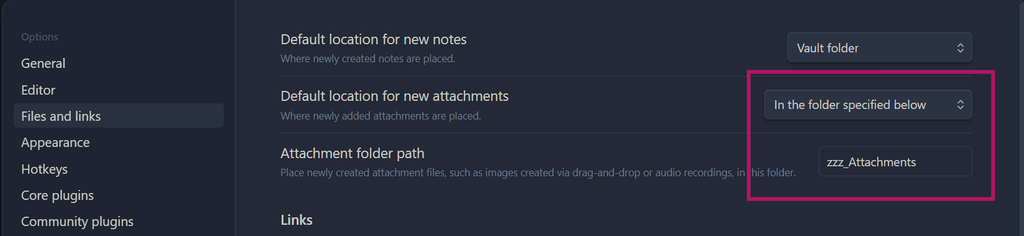

Now add an image or screenshot to one of your notes (drag and drop or copy/paste) and check that it ends up in the attachments folder.

## Part 6: Use the command palette

The command palette lets you do everything in Obsidian from your keyboard.

- Open the command palette with **Ctrl/Cmd + P**
- Type “table” and select **Insert table** to add a table to one of your notes
- Look at what else you can do, e.g. type “PDF” to export a note as PDF

## Optional tasks (if you finish early)

Pick the one you find most interesting. You don’t need to do all of them.

### Try different ways of opening a note

- **Click:** open the note
- **Ctrl/Cmd + click:** open in a new tab
- **Ctrl/Cmd + hover:** open a preview (and you can edit from there)

### Try more Markdown

Try something new from the Markdown cheatsheet, e.g. embed a note or add a callout.

### Add tags and try search

- Add tags to your notes (e.g. tag all paper notes with `#paper`)
- Click a tag to open search and see all notes with that tag

### Change the editor theme

Obsidian comes with many different editor themes you can choose from. Change the theme like this:

- Open **Settings** (gear icon bottom left corner)
- Go to **Appearance**
- Under **Themes**, click **Manage**
- Browse and install a theme (you can always switch back)

### Create a mind map

Obsidian has a digital whiteboard called **Canvas**. You can use it for mind maps, brainstorming or to get an overview.

- Create a new Canvas (icon in the left ribbon or via the command palette)
- Add cards, connect them with arrows, color and group them
- Drag and drop one of your notes onto the Canvas

Next: Exercise 2: Daily notes · Back to the workshop page